# The ‘gfilinreg’ package

The main function of the ‘gfilinreg’ package, namely `gfilinreg`, returns some weighted samples of the generalized fiducial distribution of the parameters of a linear regression model whose error terms are distributed according to a Gaussian, Student, Cauchy, or a logistic distribution.

Let’s have a look at a simple linear regression model with Gaussian errors:

```r
library(gfilinreg)
set.seed(666L)
x <- rgamma(6L, shape = 10, rate = 1)
y <- rnorm(6L, mean = x, sd = 2)
dat <- data.frame(x = x, y = y)
fidsamples <- gfilinreg(y ~ x, data = dat, distr = "normal", L = 150L)
```

The algorithm involves a partition of the hypercube ${(0,1)}^{p+1}$, where $p$ is the dimension of the model (the number of columns of the $X$ matrix), and the integer argument `L` of the `gfilinreg` function is the desired number of subdivisions of each edge of the hypercube.

A quick summary of the fiducial samples is provided by the `gfiSummary` function:

```r
gfiSummary(fidsamples)
```

```
#>                  mean    median        lwr      upr
#> (Intercept) -2.916005 -2.916129 -8.7581417 2.923371
#> x            1.289711  1.289734  0.7713491 1.808085
#> sigma        1.944718  1.693630  0.9295166 4.457853
#> attr(,"confidence level")
#> [1] 0.95
```

Let’s compare with `lm`:

```r
lmfit <- lm(y ~ x, data = dat)
coefficients(lmfit)
```

```
#> (Intercept)           x
#>   -2.916874    1.289811
```

```r
sigma(lmfit)
```

```
#> [1] 1.551726
```

```r
confint(lmfit)
```

```
#>                 2.5 %   97.5 %
#> (Intercept) -8.757421 2.923674
#> x            0.771654 1.807969
```

Excepted for the scale parameter $\sigma$, results are very similar.

One can generate simulations of fiducial predictive distributions and, based on these distributions, one can get fiducial prediction intervals:

```r
new <- data.frame(x = c(9, 10, 11))
fidpred <- gfilinregPredictive(fidsamples, newdata = new)
gfiSummary(fidpred)
```

```
#>         mean    median      lwr      upr
#> y1  8.690240  8.689795 3.954899 13.43014
#> y2  9.981746  9.985785 5.306697 14.63514
#> y3 11.276563 11.277286 6.601984 15.93058
#> attr(,"confidence level")
#> [1] 0.95
```

```r
predict(lmfit, newdata = new, interval = "prediction")
```

```
#>         fit      lwr      upr
#> 1  8.691428 3.950576 13.43228
#> 2  9.981240 5.311629 14.65085
#> 3 11.271051 6.615751 15.92635
```

Again, there is a strong agreement between the fiducial results and the frequentist results.

## A small simulation study with Cauchy errors

Now we perform some simulations of a “t-test model” with Cauchy errors, we store the fiducial summaries for each simulated dataset and we also store the maximum likelihood estimates thanks to the ‘heavy’ package. We simulate $500$ datasets.

```r
library(gfilinreg)
library(heavy)
library(data.table)

nsims <- 500L
MAXLHD <- matrix(NA_real_, nrow = nsims, ncol = 3L)
colnames(MAXLHD) <- c("group1", "group2", "sigma")
FIDlist <- vector("list", length = nsims)

group <- gl(2L, 6L)
set.seed(666L)

for(i in 1L:nsims){
  # simulated dataset
  dat <- data.frame(
    group = group,
    y = c(rcauchy(6L), 2 + rcauchy(6L))
  )
  # max-likelihood estimates
  hfit <- heavyLm(y ~ 0 + group, data = dat, family = Cauchy())
  MAXLHD[i, ] <- c(hfit[["coefficients"]], sqrt(hfit[["sigma2"]]))
  # fiducial stuff
  fidsamples <- gfilinreg(y ~ 0 + group, data = dat, L = 100L, distr = "cauchy")
  FIDlist[[i]] <- cbind(
    parameter = c("group1", "group2", "sigma"),
    as.data.table(gfiSummary(fidsamples))
  )
}
FID <- rbindlist(FIDlist)
```

The above simulations are not performed in this vignette. They are available in the package:

```r
library(data.table)
data("FID")
data("MAXLHD")
```

### Estimates

Our three estimates of the `group1` parameter (maximum likelihood, fiducial mean, fiducial median) have a similar distribution:

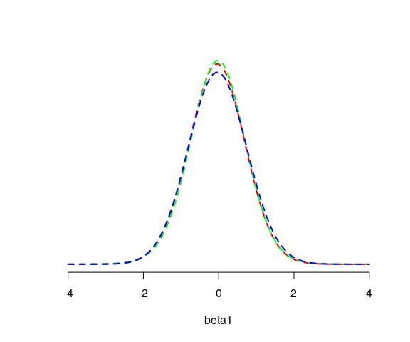

```r
library(kde1d)
group1_maxlhd     <- MAXLHD[, "group1"]
group1_fid_mean   <- FID[parameter == "group1"][["mean"]]
group1_fid_median <- FID[parameter == "group1"][["median"]]

kfit_maxlhd     <- kde1d(group1_maxlhd, mult = 4)
kfit_fid_mean   <- kde1d(group1_fid_mean, mult = 4)
kfit_fid_median <- kde1d(group1_fid_median, mult = 4)

curve(
  dkde1d(x, kfit_maxlhd), from = -4, to = 4, axes = FALSE,
  lwd = 2, col = "red", lty = "dashed", xlab = "beta1", ylab = NA
)
axis(1)
curve(
  dkde1d(x, kfit_fid_mean), add = TRUE,
  lwd = 2, col = "green", lty = "dashed"
)
curve(
  dkde1d(x, kfit_fid_median), add = TRUE,
  lwd = 2, col = "blue", lty = "dashed"
)
```

A simulated dataset has yielded aberrant values of the fiducial mean and the fiducial medians (I do not know why, perhaps a matrix at the edge of non-invertibility has been inversed). After removing it, one observes that the distributions of the three estimates of the `group2` parameter are similar:

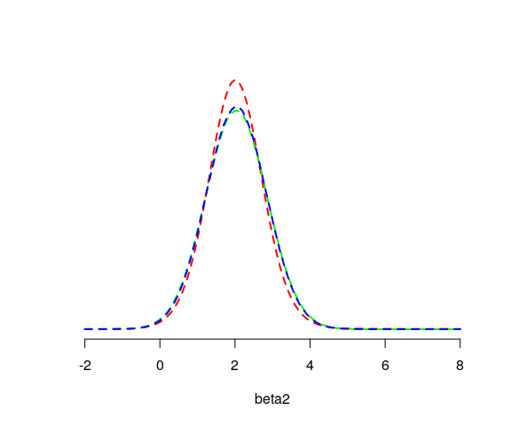

```r
group2_maxlhd     <- MAXLHD[, "group2"]
group2_fid_mean   <- FID[parameter == "group2"][["mean"]][-333L]
group2_fid_median <- FID[parameter == "group2"][["median"]][-333L]

kfit_maxlhd     <- kde1d(group2_maxlhd, mult = 4)
kfit_fid_mean   <- kde1d(group2_fid_mean, mult = 4)
kfit_fid_median <- kde1d(group2_fid_median, mult = 4)

curve(
  dkde1d(x, kfit_maxlhd), from = -2, to = 8, axes = FALSE,
  lwd = 2, col = "red", lty = "dashed", xlab = "beta2", ylab = NA
)
axis(1)
curve(
  dkde1d(x, kfit_fid_mean), add = TRUE,
  lwd = 2, col = "green", lty = "dashed"
)
curve(
  dkde1d(x, kfit_fid_median), add = TRUE,
  lwd = 2, col = "blue", lty = "dashed"
)
```

For the scale parameter `sigma`, there are some differences. The maximum likelihood estimates often underestimate the true value, and the true value is close to the median of the fiducial medians:

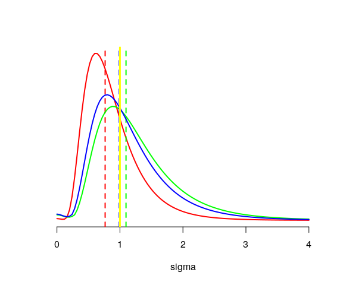

```r
sigma_maxlhd     <- MAXLHD[, "sigma"]
sigma_fid_mean   <- FID[parameter == "sigma"][["mean"]][-333L]
sigma_fid_median <- FID[parameter == "sigma"][["median"]][-333L]

kfit_maxlhd     <- kde1d(sigma_maxlhd, xmin = 0, mult = 4)
kfit_fid_mean   <- kde1d(sigma_fid_mean, xmin = 0, mult = 4)
kfit_fid_median <- kde1d(sigma_fid_median, xmin = 0, mult = 4)

curve(
  dkde1d(x, kfit_maxlhd), from = 0, to = 4, axes = FALSE,
  lwd = 2, col = "red", xlab = "sigma", ylab = NA
)
axis(1)
abline(v = median(sigma_maxlhd), col = "red", lwd = 2, lty = "dashed")
curve(
  dkde1d(x, kfit_fid_mean), add = TRUE,
  lwd = 2, col = "green"
)
abline(v = median(sigma_fid_mean), col = "green", lwd = 2, lty = "dashed")
curve(
  dkde1d(x, kfit_fid_median), add = TRUE,
  lwd = 2, col = "blue"
)
abline(v = median(sigma_fid_median), col = "blue", lwd = 2, lty = "dashed")
# true value:
abline(v = 1, col = "yellow", lwd = 3)
```

### Frequentist coverage

Below are the coverage probabilities of the fiducial confidence intervals estimated from the $500$ simulations.

```r
# group1
group1 <- FID[parameter == "group1"]
mean(group1[["lwr"]] < 0)
```

```
#> [1] 0.978
```

```r
mean(0 < group1[["upr"]])
```

```
#> [1] 0.97
```

```r
mean(group1[["lwr"]] < 0 & 0 < group1[["upr"]])
```

```
#> [1] 0.948
```

```r
# group2
group2 <- FID[parameter == "group2"]
mean(group2[["lwr"]] < 2)
```

```
#> [1] 0.976
```

```r
mean(2 < group2[["upr"]])
```

```
#> [1] 0.972
```

```r
mean(group2[["lwr"]] < 2 & 2 < group2[["upr"]])
```

```
#> [1] 0.948
```

```r
# sigma
sigma <- FID[parameter == "sigma"]
mean(sigma[["lwr"]] < 1)
```

```
#> [1] 0.928
```

```r
mean(1 < sigma[["upr"]])
```

```
#> [1] 0.976
```

```r
mean(sigma[["lwr"]] < 1 & 1 < sigma[["upr"]])
```

```
#> [1] 0.904
```

For the parameters `group1` and `group2`, the coverage probabilities are close to the nominal level. For `sigma`, only the upper bound yields a coverage probability close to the nominal level. The lower bound is too large on average. But remember that the datasets we simulated are small ($6$ observations per group).